# IE6400 Foundations for Data Analytics Engineering

# Fall 2023

### Module 2: Data and Sampling Distributions

#### Data Distribution:

A data distribution refers to the way in which a set of data points is spread or distributed. When you collect data and plot it on a graph, the shape that data takes can be referred to as its distribution.

#### Sampling Distribution:

A sampling distribution is a probability distribution of a statistic obtained through a large number of samples drawn from a specific population. The sampling distribution of a given population is the distribution of frequencies of a range of different outcomes that could possibly occur for a statistic of a population.

### 1. Population and Sample

A **population** is a complete set of people with a specialized set of characteristics, and a **sample** is a subset of the population.

A **population** is the entire group that you want to draw conclusions about.

A **sample** is the specific group that you will collect data from. The size of the sample is always less than the total size of the population. To get sample, a *sampling procedure* is used.

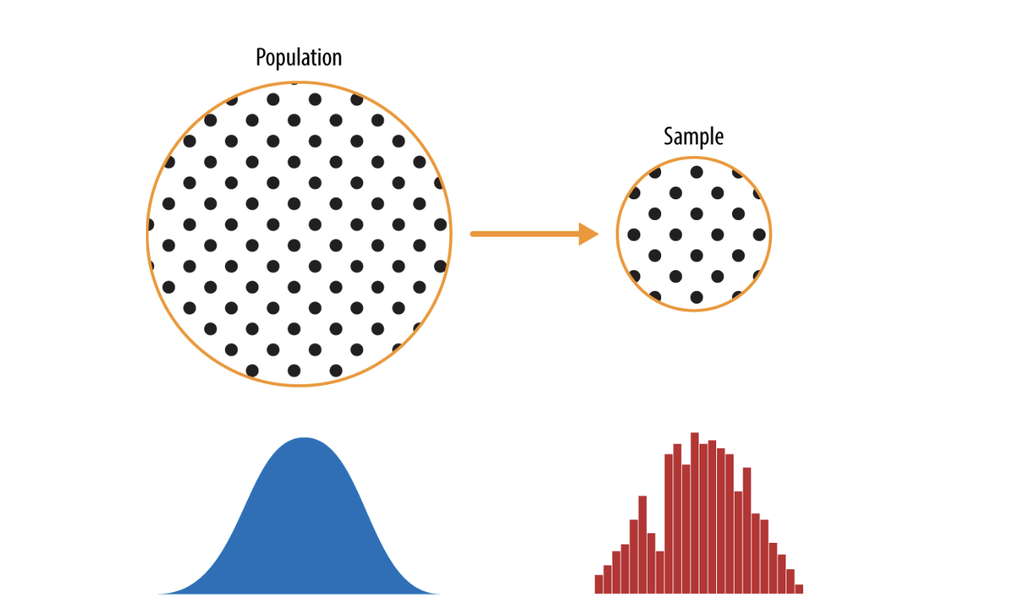

In general, data scientists need not worry about the theoretical nature of the population, and instead should focus on the sampling procedures and the data at hand.

#### Sampling Procedure

To draw valid conclusions from your results, you have to carefully decide how you will select a sample that is representative of the group as a whole. This is called a sampling method. There are two primary types of sampling methods that you can use in your research:

- Probability sampling involves random selection, allowing you to make strong statistical inferences about the whole group.
- Non-probability sampling involves non-random selection based on convenience or other criteria, allowing you to easily collect data.

## Probabilistic Sampling Methods

**Probability sampling** means that every member of the population has a chance of being selected. If you want to produce results that are representative of the whole population, probability sampling techniques are the most valid choice.

#### Excercise 1 Random sample without replacement

*Random* is module implements pseudo-random number generators for many distributions.

```python
import random
```

We will use the following function to choose sample items from a Python list, set, and dictionary. We will also see how to generate a random sample array from a sizeable multidimensional array in Python:

### Simple Random Sample

#### random.sample()

random.sample() returns a k length list of unique elements chosen from the population sequence. Used for random sampling without replacement. We need to specify population and sample size to draw from population.

#### Specifying population:

```python
aList = [20, 40, 80, 100, 120]
```

Drawing sample from population with a sample size 3:

```python
sampled_list = random.sample(aList, 3)
```

Printing sample:

```python
print(sampled_list)
```

```
[80, 40, 20]
```

Sample of 3 without replacement is obtained.

Now, let's try to draw sample of size 4 from population using the same function:

#### Specifying population:

```python
exampleList = [20, 40, 20, 20, 40, 60, 70]
```

Drawing sample from population with a sample size 4:

```python
sampled_list2 = random.sample(exampleList, 4) # choosing 4 random items from a list
```

Printing sample:

```python
print(sampled_list2)
```

```
[40, 70, 40, 20]
```

Sample of 4 without replacement is obtained.

#### Exercise 2 Random sample with replacement

To draw sample with replacement, we can use the same module with different function:

#### random.choices()

random.choices() function returns a k sized list of elements chosen from the population with replacement. If the population is empty, raises IndexError.

#### Specifying population:

```python
names = ["Roger", "Nadal", "Novac", "Andre", "Sarena", "Mariya", "Martina"]
```

Drawing sample from population with a sample size of 3:

```python
sample_list3 = random.choices(names, k=3)
```

Printing sample:

```python
print(sample_list3)
```

```
['Andre', 'Andre', 'Andre']
```

Sample with replacement is obtained. In sampling with replacement you can obtain same observation from population more than once, which is not the case for sampling without replacement (unless your population contains repeated observations)

#### Exercise 3 Generate the sampled list of random integers

If you want to draw sample without replacement from a range of integers, you can use combination of sample() function and range()

Specyfing population as range of 100 and sample size of 5:

```python
num_list = random.sample(range(100), 5)
```

Printing sample:

```python
print(num_list)
```

```
[64, 87, 41, 75, 91]
```

We can shuffle existing sample by using shuffle() function

```python
random.shuffle(num_list)
```

Printing sample:

```python
print(num_list)
```

```
[87, 91, 75, 41, 64]
```

#### Exercise 4 Random sample from the Python set

If we have population as a Python set instead of list, we can convert it to list and draw sample:

Creating population as Python set:

```python
aSet = {"Jhon", "kelly", "Scoot", "Emma", "Eric"}
```

Converting set to list:

```python
aList = list(aSet)
```

Drawing a sample of 3 from converted set:

```python
sampled_elements = random.sample(aList, 3)
```

Printing sample:

```python
print(sampled_elements)
```

```
['Scoot', 'Eric', 'Emma']
```

Notice that the result is a Python list.

#### Exercise 5 Random Sample from Python dictionary

Specyfing population as Python dictionary:

```python
marks_dict = {
    "Kelly": 55,
    "jhon": 70,
    "Donald": 60,
    "Lennin": 50
}
```

Drawing sample with replacement from population. As population we pass our dictionary converted to list:

```python
sampled_items = random.choices(list(marks_dict.items()), k=2)
```

Converting sample back to dictionary:

```python
sampled_dict = dict(sampled_items)
```

Printing sample:

```python
print(sampled_dict)
```

```
{'jhon': 70, 'Donald': 60}
```

Output will be a dictionary with 2 randomly sampled key-value pairs.

We can access key-value from sample:

```python
print(sampled_dict[list(sampled_dict.keys())[0]], sampled_dict[list(sampled_dict.keys())[1]])
```

```
70 60
```

```python
print(sampled_dict[list(sampled_dict.keys())[1]], sampled_dict[list(sampled_dict.keys())[0]])
```

```
60 70
```

#### Exercise 6 Random seed to get the same sample list every time

random.seed() function is used to initialize a random number generator

Specifying population:

```python
alist = [20.5, 40.5, 30.5, 50.5, 70.5]
```

Creating a loop with random number in random.seed(). Sampling using random.sample() function from population and sample size 3:

```python
for i in range(1):
    # use 4 as a seed value
    random.seed(4)
    # get sample list of three item
    sample_list = random.sample(alist, 3)
    print(sample_list)
```

```
[40.5, 30.5, 20.5]
```

By looping and using random.seed() we get same sample every time we run code cell. Let's try changing seed to another number:

```python
for i in range(1):
    # use 3 as a seed value
    random.seed(3)
    # get sample list of three item
    sample_list = random.sample(alist, 3)
    print(sample_list)
```

```
[40.5, 70.5, 50.5]
```

Using different seed number generated different sample of the same sample size.

#### Exercise 7 Get a sample array from a multidimensional array

```python
import numpy as np
```

Specifying population as an array

```python
array = np.array([[2, 4, 6], [5, 10, 15], [6, 12, 18], [7, 14, 21], [8, 16, 24]])
```

To draw sample from numpy array we can use numpy.random.randint() function:

```python
randomRows = np.random.randint(5, size=2)
```

```python
for i in randomRows:
    print(array[i, :])
```

```
[ 7 14 21]
[ 8 16 24]
```

This sampling works as sampling with replacement.

### Biased Sampling

Sampling bias occurs when some members of a population are systematically more likely to be selected in a sample than others.

Sampling bias limits the generalizability of findings because it is a threat to external validity, specifically population validity. In other words, findings from biased samples can only be generalized to populations that share characteristics with the sample.

#### Exercise 8 Biased Sampling Using Random module

Specifying population:

```python
items = ["A", "B", "C", "D"]
```

Specifying weights for each item in population:

```python
weights = [0.2, 0.3, 0.4, 0.1]
```

Defining sample size:

```python
sample_size = 3
```

Perform biased sampling using random.choices(), specyfing defined weights and sample size:

```python
sampled_items = random.choices(items, weights=weights, k=sample_size)
```

Printing sample:

```python
print("Sampled items:", sampled_items)
```

```
Sampled items: ['D', 'B', 'C']
```

#### Exercise 9 Biased Sampling using NumPy module

Defining a custom probability distribution function that assigns higher probability to even numbers:

```python
def custom_prob_distribution(x):
    if x % 2 == 0:
        return 0.6
    else:
        return 0.4
```

Creating an array of items:

```python
items = np.array([1, 2, 3, 4, 5, 6, 7, 8, 9, 10])
```

Calculating probabilities based on the custom distribution:

```python
probabilities = np.array([custom_prob_distribution(x) for x in items])
```

```python
print(probabilities)
```

```
[0.4 0.6 0.4 0.6 0.4 0.6 0.4 0.6 0.4 0.6]
```

Normalizing probabilities:

```python
probabilities /= probabilities.sum()
```

Defining sample size:

```python
sample_size = 5
```

Drawing sampled indices using numpy.random.choice() function. Setting replace as False and probabilities:

```python
sampled_indices = np.random.choice(len(items), size=sample_size, replace=False, p=probabilities)
```

Defining sampled items:

```python
sampled_items = items[sampled_indices]
```

Printing sample:

```python
print("Sampled items:", sampled_items)
```

```
Sampled items: [ 1  8  6 10  9]
```

As a result, we get a sample where majority of numbers are even because they have higher probability.

#### Exercise 10 Biased Sampling using Roulette Wheel Selection

Defining a list of individuals with fitness scores:

```python
individuals = [("A", 0.2), ("B", 0.3), ("C", 0.4), ("D", 0.1)]
```

Calculating cumulative fitness values:

```python
cumulative_fitness = [sum([ind[1] for ind in individuals[:i+1]]) for i in range(len(individuals))]
```

```python
print(cumulative_fitness)
```

```
[0.2, 0.5, 0.9, 1.0]
```

Defining sample size:

```python
sample_size = 3
```

Creating a sample list for sampled individuals:

```python
sampled_individuals = []
```

Performing biased sampling using roulette wheel selection:

```python
for _ in range(sample_size):
    rand_value = random.random()  # Generate a random value between 0 and 1
    selected_index = None

    # Find the index of the individual whose cumulative fitness is greater than rand_value
    for i, fitness in enumerate(cumulative_fitness):
        if rand_value <= fitness:
            selected_index = i
            break

    sampled_individuals.append(individuals[selected_index][0]) # Append individuals with selected index to empty list
```

Printing sample:

```python
print("Sampled individuals:", sampled_individuals)
```

```
Sampled individuals: ['C', 'D', 'B']
```

### Stratified Sampling

Stratified Sampling is a sampling technique used to obtain samples that best represent the population. It reduces bias in selecting samples by dividing the population into homogeneous subgroups called strata, and randomly sampling data from each stratum(singular form of strata).

#### Exercise 11 Stratified sampling

Creating a dictionary of students:

```python
import pandas as pd
import warnings
warnings.filterwarnings('ignore')

students = [
    {'Name': 'Lisa', 'ID': '001', 'Grade': 'A', 'Category': 2},
    {'Name': 'Kate', 'ID': '002', 'Grade': 'A', 'Category': 3},
    {'Name': 'Ben', 'ID': '003', 'Grade': 'C', 'Category': 1},
    {'Name': 'Kim', 'ID': '004', 'Grade': 'B', 'Category': 3},
    {'Name': 'Josh', 'ID': '005', 'Grade': 'B', 'Category': 2},
    {'Name': 'Alex', 'ID': '006', 'Grade': 'B', 'Category': 3},
    {'Name': 'Evan', 'ID': '007', 'Grade': 'C', 'Category': 3},
    {'Name': 'Greg', 'ID': '008', 'Grade': 'A', 'Category': 1},
    {'Name': 'Sam', 'ID': '009', 'Grade': 'A', 'Category': 2},
    {'Name': 'Ella', 'ID': '010', 'Grade': 'A', 'Category': 1}
]
```

Creating dataframe from students dictionary:

```python
df = pd.DataFrame(students)
```

Viewing the dataframe:

```python
df
```

|  | Name | ID | Grade | Category |
| --- | --- | --- | --- | --- |
| 0 | Lisa | 001 | A | 2 |
| 1 | Kate | 002 | A | 3 |
| 2 | Ben | 003 | C | 1 |
| 3 | Kim | 004 | B | 3 |
| 4 | Josh | 005 | B | 2 |
| 5 | Alex | 006 | B | 3 |
| 6 | Evan | 007 | C | 3 |
| 7 | Greg | 008 | A | 1 |
| 8 | Sam | 009 | A | 2 |
| 9 | Ella | 010 | A | 1 |

Stratified sampling divides the population into groups based on a category, like grade level, and randomly selects two individuals from each group to ensure equal representation. This method avoids disproportionate sampling.

```python
df.groupby('Grade', group_keys=False).apply(lambda x: x.sample(2))
```

|  | Name | ID | Grade | Category |
| --- | --- | --- | --- | --- |
| 8 | Sam | 009 | A | 2 |
| 7 | Greg | 008 | A | 1 |
| 5 | Alex | 006 | B | 3 |
| 4 | Josh | 005 | B | 2 |
| 6 | Evan | 007 | C | 3 |
| 2 | Ben | 003 | C | 1 |

Another way to define a sample is to use the frac parameter, which considers the size of each strata in the population. This is known as proportionate sampling.

```python
df.groupby('Grade', group_keys=False).apply(lambda x: x.sample(frac=0.6))
```

|  | Name | ID | Grade | Category |
| --- | --- | --- | --- | --- |
| 8 | Sam | 009 | A | 2 |
| 1 | Kate | 002 | A | 3 |
| 7 | Greg | 008 | A | 1 |
| 3 | Kim | 004 | B | 3 |
| 4 | Josh | 005 | B | 2 |
| 6 | Evan | 007 | C | 3 |

We obtained a sample of 6 students by setting the frac parameter to 0.6. Within this sample, 3 out of 5 A students were included, as well as 2 out of 3 B students and 1 out of 2 C students. This approach to sampling is known as proportionate sampling and takes into consideration the size of each strata in the population.

### Systematic Sampling

Systematic sampling is a method that involves selecting every nth element from the population, where "n" is a constant determined by the sampling interval. This method is useful when you want to ensure a random and representative sample without going through the entire population.

#### Exercise 12 Systematic Sampling

Defining total number of students:

```python
number_of_students = 15
```

Creating data dictionary:

```python
data = {'Id': np.arange(1, number_of_students+1).tolist(),
        'height': [159, 171, 158, 162, 162, 177, 160, 175,
                   168, 171, 178, 178, 173, 177, 164]}
```

Transform dictionary into a data frame

```python
df = pd.DataFrame(data)
```

Displaying dataframe:

```python
display(df)
```

|  | Id | height |
| --- | --- | --- |
| 0 | 1 | 159 |
| 1 | 2 | 171 |
| 2 | 3 | 158 |
| 3 | 4 | 162 |
| 4 | 5 | 162 |
| 5 | 6 | 177 |
| 6 | 7 | 160 |
| 7 | 8 | 175 |
| 8 | 9 | 168 |
| 9 | 10 | 171 |
| 10 | 11 | 178 |
| 11 | 12 | 178 |
| 12 | 13 | 173 |
| 13 | 14 | 177 |
| 14 | 15 | 164 |

Defining systematic sampling function. Step is nth number to choose from population:

```python
def systematic_sampling(df, step):

    indexes = np.arange(0, len(df), step=step)
    systematic_sample = df.iloc[indexes]
    return systematic_sample
```

Obtaining a systematic sample and save it in a new variable:

```python
systematic_sample = systematic_sampling(df, 3)
```

Viewing sampled data frame:

```python
systematic_sample
```

|  | Id | height |
| --- | --- | --- |
| 0 | 1 | 159 |
| 3 | 4 | 162 |
| 6 | 7 | 160 |
| 9 | 10 | 171 |
| 12 | 13 | 173 |

#### Exercise 13 Setting step and start for systematic sampling

Step should be chosen as following: population size /sample size. Then randomly choose number from 1 to previously defined as start and start sampling with step from start:

Setting sample size:

```python
sample_size = 5
```

Setting step and converting to integer:

```python
step = int(round(len(df)/sample_size,0))
```

Setting start index as random number between 1 and step:

```python
start_index = random.randint(1, step)
```

Defining sample from start index and step:

```python
sampled_df = df.iloc[start_index::step]
```

Viewing sample:

```python
sampled_df
```

|  | Id | height |
| --- | --- | --- |
| 3 | 4 | 162 |
| 6 | 7 | 160 |
| 9 | 10 | 171 |
| 12 | 13 | 173 |

### Cluster Sampling

Cluster sampling is a sampling technique used in statistics and research to select a sample from a large population that is divided into clusters or groups. Unlike simple random sampling, where individual elements are selected randomly from the entire population, cluster sampling involves randomly selecting entire clusters and then sampling all the elements within those selected clusters.

#### Exercise 14 Cluster Sampling

Creating a population:

```python
import pandas as pd
import numpy as np

df = pd.DataFrame({'tour': np.repeat(np.arange(1,11), 20),
                   'experience': np.random.normal(loc=7, scale=1, size=200)})
```

```python
df.head(5)
```

|  | tour | experience |
| --- | --- | --- |
| 0 | 1 | 7.603700 |
| 1 | 1 | 9.033334 |
| 2 | 1 | 5.337571 |
| 3 | 1 | 8.001855 |
| 4 | 1 | 7.328087 |

In this example we have 10 tours and experience of customers for each tour.

Randomly choosing 4 tour groups out of the 10:

```python
clusters = np.random.choice(np.arange(1,11), size=4, replace=False)
```

Defining sample as all members who belong to one of the 4 tour groups:

```python
cluster_sample = df[df['tour'].isin(clusters)]
```

View first six rows of sample:

```python
cluster_sample.head(6)
```

|  | tour | experience |
| --- | --- | --- |
| 40 | 3 | 7.269765 |
| 41 | 3 | 6.553195 |
| 42 | 3 | 7.253013 |
| 43 | 3 | 5.230209 |
| 44 | 3 | 5.918241 |
| 45 | 3 | 7.515962 |

Viewing how many customers are in each tour:

```python
cluster_sample['tour'].value_counts()
```

```
3    20
4    20
7    20
9    20
Name: tour, dtype: int64
```

This is our final sample. Cluster sampling can be more efficient than simple random sampling when the clusters are relatively homogeneous internally. It reduces the cost and time required for data collection

## Non-Probabilistic Sampling Methods

In a non-probability sample, individuals are selected based on non-random criteria, and not every individual has a chance of being included.

This type of sample is easier and cheaper to access, but it has a higher risk of sampling bias.

### Convenience Sampling

Convenience sampling is a non-probability sampling technique where you select a sample that is easily accessible or convenient to collect, rather than using random or structured methods.

#### Exercise 15 Convenience Sampling

Creating a dataset:

```python
data = {
    'Name': ['Alice', 'Bob', 'Charlie', 'David', 'Eve', 'Frank', 'Grace', 'Helen', 'Ivy', 'Jack'],
    'Age': [25, 30, 22, 35, 28, 19, 42, 29, 31, 40],
    'Gender': ['Female', 'Male', 'Male', 'Male', 'Female', 'Male', 'Female', 'Female', 'Female', 'Male']
}
```

```python
df = pd.DataFrame(data)
df
```

|  | Name | Age | Gender |
| --- | --- | --- | --- |
| 0 | Alice | 25 | Female |
| 1 | Bob | 30 | Male |
| 2 | Charlie | 22 | Male |
| 3 | David | 35 | Male |
| 4 | Eve | 28 | Female |
| 5 | Frank | 19 | Male |
| 6 | Grace | 42 | Female |
| 7 | Helen | 29 | Female |
| 8 | Ivy | 31 | Female |
| 9 | Jack | 40 | Male |

Performing convenience sampling by selecting a subset of the data (e.g., first 5 rows):

```python
convenience_sample = df.head(5)
```

Viewing convenience sample:

```python
print(convenience_sample)
```

```
      Name  Age  Gender
0    Alice   25  Female
1      Bob   30    Male
2  Charlie   22    Male
3    David   35    Male
4      Eve   28  Female
```

As a result, we get non-random sample with first 5 rows, which do not represent population (e.g. we do not have anyone older than 40)

### Purposive Sampling

Purposive sampling, also known as judgmental or selective sampling, is a non-probability sampling technique used in research to select a sample based on specific criteria or the researcher's judgment. Unlike random sampling methods, purposive sampling involves deliberately choosing individuals or elements from the population that possess certain characteristics or knowledge relevant to the research question.

#### Exercise 16 Purposive Sampling

Using same population dataset, for our sample we want to pick people only older than 30:

```python
purposive_sample = df[df['Age'] > 30]
```

Viewing sample:

```python
print(purposive_sample)
```

```
    Name  Age  Gender
3  David   35    Male
6  Grace   42  Female
8    Ivy   31  Female
9   Jack   40    Male
```

Resulting sample does not represent population as it does not include people younger than 30.

### Snowball Sampling

Snowball sampling is a non-probability sampling technique commonly used in social research, especially when studying hard-to-reach or hidden populations. It is a method of sampling where initial participants are selected, and then they help identify and recruit additional participants who meet the research criteria. The process continues like a snowball rolling down a hill, gradually accumulating more participants.

#### Exercise 17 Snowball Sampling

Using the same population dataset, we start by setting initial participant:

```python
initial_participant = ['Alice']
```

Performing a simplified snowball sampling where each participant refers the next one:

```python
while len(initial_participant) < 5:  # Select 5 participants
    # Randomly select a participant from the dataset
    selected_participant = df.sample(1)['Name'].values[0]

    # Add the selected participant to the list
    initial_participant.append(selected_participant)
```

Creating a snowball sample based on the selected participants:

```python
snowball_sample = df[df['Name'].isin(initial_participant)]
```

Viewing sample:

```python
print(snowball_sample)
```

```
    Name  Age  Gender
0  Alice   25  Female
1    Bob   30    Male
4    Eve   28  Female
5  Frank   19    Male
8    Ivy   31  Female
```

Resulting sample is again non-representative of population as not every person has an equal chance to be included in sample (only those who know Alice)

### Quota Sampling

Quota sampling is a non-probability sampling technique used in research to create a sample that is representative of a larger population with specific characteristics or attributes. In quota sampling, the researcher divides the population into subgroups or strata based on certain criteria, such as age, gender, income, or education. The researcher then sets quotas for each subgroup based on the desired proportions in the final sample. Individuals are then selected non-randomly to fill these quotas until they are met.

#### Exercise 18 Quota Sampling

Creating a population dataset:

```python
data = {
    'Gender': ['Male', 'Female', 'Male', 'Male', 'Female', 'Female', 'Male', 'Male', 'Female', 'Male'],
    'Age': [25, 30, 22, 35, 28, 19, 42, 29, 31, 40],
    'Income': [50000, 60000, 45000, 75000, 55000, 40000, 90000, 62000, 71000, 80000]
}
```

```python
df = pd.DataFrame(data)
df
```

|  | Gender | Age | Income |
| --- | --- | --- | --- |
| 0 | Male | 25 | 50000 |
| 1 | Female | 30 | 60000 |
| 2 | Male | 22 | 45000 |
| 3 | Male | 35 | 75000 |
| 4 | Female | 28 | 55000 |
| 5 | Female | 19 | 40000 |
| 6 | Male | 42 | 90000 |
| 7 | Male | 29 | 62000 |
| 8 | Female | 31 | 71000 |
| 9 | Male | 40 | 80000 |

Defining quota criteria:

```python
gender_quota = {'Male': 2, 'Female': 2}
```

```python
age_groups = {'Age 18-24': (18, 24), 'Age 25-34': (25, 34), 'Age 35-44': (35, 44)}
```

Initializing empty quota sample DataFrame:

```python
quota_sample = pd.DataFrame(columns=df.columns)
```

Creating the quota sample by filling quotas based on criteria:

```python
for gender, gender_quota_count in gender_quota.items():
    for age_group, (start, end) in age_groups.items():
        # Select participants that meet the gender and age criteria
        eligible_participants = df[(df['Gender'] == gender) & (df['Age'].between(start, end))]

        # If there are enough eligible participants to meet the quota, add them to the quota sample
        if len(eligible_participants) >= gender_quota_count:
            selected_participants = eligible_participants.sample(gender_quota_count, random_state=42)
            quota_sample = quota_sample.append(selected_participants)
```

Viewing sample:

```python
print(quota_sample)
```

```
   Gender Age Income
7    Male  29  62000
0    Male  25  50000
3    Male  35  75000
6    Male  42  90000
1  Female  30  60000
4  Female  28  55000
```

Quota sampling does not represent population, but it contains observations satisfying desired parameters.

## Descriptive Statistics

Descriptive statistics is about describing and summarizing data. It uses two main approaches:

- The quantitative approach describes and summarizes data numerically.
- The visual approach illustrates data with charts, plots, histograms, and other graphs.

The are several types of measures in descriptive statistics:

- **Central tendency** tells you about the centers of the data. Useful measures include the mean, median, and mode.
- **Variability** tells you about the spread of the data. Useful measures include variance and standard deviation.
- **Correlation** or joint variability tells you about the relation between a pair of variables in a dataset. Useful measures include covariance and the correlation coefficient.

**Math** module is a built-in Python module that you can use for mathematical tasks.

```python
import math
```

**Statistics** module is a built-in Python module that you can use to calculate mathematical statistics of numeric data.

```python
import statistics
```

**SciPy** is a scientific computation library that uses NumPy underneath. SciPy stands for Scientific Python. It provides more utility functions for optimization, stats and signal processing.

```python
!pip install scipy
```

```python
import scipy.stats
```

### Central Tendency

#### Mean

The sample mean, also called the sample arithmetic mean or simply the average, is the arithmetic average of all the items in a dataset. In other words, it’s the sum of all the elements in the dataset divided by the number of items in the dataset.

#### Exercise 19 Calculating Mean

Creating a dataset:

```python
d = {'Name':pd.Series(['Tom','James','Ricky','Vin','Steve','Smith','Jack',
   'Lee','David','Gasper','Betina','Andres']),
   'Age':pd.Series([25,26,25,23,30,29,23,34,40,30,51,46]),
   'Rating':pd.Series([4.23,3.24,3.98,2.56,3.20,4.6,3.8,3.78,2.98,4.80,4.10,3.65])
}

df = pd.DataFrame(d)
print(df)
```

```
      Name  Age  Rating
0      Tom   25    4.23
1    James   26    3.24
2    Ricky   25    3.98
3      Vin   23    2.56
4    Steve   30    3.20
5    Smith   29    4.60
6     Jack   23    3.80
7      Lee   34    3.78
8    David   40    2.98
9   Gasper   30    4.80
10  Betina   51    4.10
11  Andres   46    3.65
```

Finding sum of column age:

```python
age_sum = df['Age'].sum()
age_sum
```

```
382
```

Diving by number of observations in the columns:

```python
age_mean = age_sum/len(df['Age'])
age_mean
```

```
31.833333333333332
```

We can also use built-in functions to find mean:

```python
age_mean = df['Age'].mean()
age_mean
```

```
31.833333333333332
```

#### Exercise 20 Harmonic mean

- The harmonic mean is an average calculated by dividing the number of observations. It is the reciprocal of the arithmetic mean of the reciprocals of the data. The harmonic mean is valuable in situations where the dataset contains rates.
- 𝑛 / Σᵢ(1/𝑥ᵢ), where 𝑖 = 1, 2, …, 𝑛 and 𝑛 is the number of items in the dataset 𝑥.

You can use built-in function from scipy.stats:

```python
harmonic_mean = scipy.stats.hmean(df['Age'])
harmonic_mean
```

```
29.826541973016024
```

Or manually:

```python
n = len(df['Age'])
sum_reciprocals = sum(1 / x for x in df['Age'])
harmonic_mean = n / sum_reciprocals
```

```python
harmonic_mean
```

```
29.826541973016027
```

#### Exercise 21 Trimmed mean

A trimmed mean is a statistical measure that calculates the mean of a dataset after a certain percentage of the smallest and largest values have been removed. It is a way to reduce the influence of outliers or extreme values on the mean, making it more robust to extreme data points.

Defining the percentage of data to be trimmed from both ends (e.g., 10%):

```python
trim_percent = 0.1
```

Calculating the number of data points to be trimmed:

```python
n = len(df['Age'])
k = int(n * trim_percent)
```

Sorting column:

```python
df.sort_values(by=['Age'])
```

|  | Name | Age | Rating |
| --- | --- | --- | --- |
| 3 | Vin | 23 | 2.56 |
| 6 | Jack | 23 | 3.80 |
| 0 | Tom | 25 | 4.23 |
| 2 | Ricky | 25 | 3.98 |
| 1 | James | 26 | 3.24 |
| 5 | Smith | 29 | 4.60 |
| 4 | Steve | 30 | 3.20 |
| 9 | Gasper | 30 | 4.80 |
| 7 | Lee | 34 | 3.78 |
| 8 | David | 40 | 2.98 |
| 11 | Andres | 46 | 3.65 |
| 10 | Betina | 51 | 4.10 |

```python
trimmed_mean = np.mean(df['Age'][k:n-k])
```

```python
trimmed_mean
```

```
31.1
```

#### Median

The sample median is the middle element of a sorted dataset. The dataset can be sorted in increasing or decreasing order. If the number of elements 𝑛 of the dataset is odd, then the median is the value at the middle position: 0.5(𝑛 + 1). If 𝑛 is even, then the median is the arithmetic mean of the two values in the middle, that is, the items at the positions 0.5𝑛 and 0.5𝑛 + 1.

#### Exercise 22 Median

You can use built-in function:

```python
age_median = df['Age'].median()
age_median
```

```
29.5
```

Median age in our dataset is 29.5. It is less than mean 31.8 as our data is skewed towards larger age.

#### Mode

The mode is a statistical measure that represents the most frequently occurring value in a dataset.

#### Execise 23 Mode

You can use built-in function:

```python
age_mode = df['Age'].mode()
age_mode
```

```
0    23
1    25
2    30
Name: Age, dtype: int64
```

We have 3 modes, because all three of these values appear 2 times in the dataset

#### Variance

Variance is a statistical measure that quantifies the spread or dispersion of a dataset. It provides information about how much individual data points deviate from the mean (average) of the dataset.

Population variance and sample variance both measure the dispersion or spread of data. However, they differ in the data they analyze. Population variance is calculated using the entire population data, while sample variance is calculated using a subset of the population known as a sample.

#### Exercise 24 Variance

```python
age_var = df['Age'].var(ddof=1)
age_var
```

```
85.24242424242424
```

Variance for our data is 85.24

By setting ddof=1 we are calculating sample variance

#### Standard Deviation

The standard deviation is a statistical measure of the amount of variation or dispersion in a dataset. It quantifies how individual data points deviate from the mean (average) of the dataset.

Standard deviation is a squared root of variance.

#### Exercise 25 Standard Deviation

```python
age_std = df['Age'].std()
age_std
```

```
9.232682396921506
```

On average, age points in our dataset deviate by 9 years from the mean.

#### Range

The range is a simple statistical measure that represents the spread or dispersion of data in a dataset. It is the difference between the maximum and minimum values in the dataset. In other words, it provides a measure of how much the data values vary from each other.

#### Exercise 26 Range

```python
age_range = max(df['Age']) - min(df['Age'])
age_range
```

```
28
```

Range between maximum and minimum ages in our dataset is 28.

#### Interquartile Range

The interquartile range (IQR) is a statistical measure of the spread or dispersion of a dataset. It represents the range between the first quartile (25th percentile) and the third quartile (75th percentile) of the data when it is ordered in ascending or descending order. The IQR is useful because it is less sensitive to outliers compared to the range, which is based on the minimum and maximum values.

#### Exercise 27 IQR

Finding first percentile:

```python
q1 = np.percentile(df['Age'], 25)
```

Finding third percentile:

```python
q3 = np.percentile(df['Age'], 75)
```

Finding IQR:

```python
iqr = q3 - q1
iqr
```

```
10.5
```

### Summarizing Data

Summarizing data is an essential step in data analysis and reporting. It involves presenting key statistics and insights about a dataset to help understand its characteristics.

#### Exercise 28 Summarizing Data

The describe() function computes a summary of statistics pertaining to the DataFrame columns.

```python
df.describe()
```

|  | Age | Rating |
| --- | --- | --- |
| count | 12.000000 | 12.000000 |
| mean | 31.833333 | 3.743333 |
| std | 9.232682 | 0.661628 |
| min | 23.000000 | 2.560000 |
| 25% | 25.000000 | 3.230000 |
| 50% | 29.500000 | 3.790000 |
| 75% | 35.500000 | 4.132500 |
| max | 51.000000 | 4.800000 |

This function gives the mean, std and IQR values. And, function excludes the character columns and given summary about numeric columns. 'include' is the argument which is used to pass necessary information regarding what columns need to be considered for summarizing. Takes the list of values; by default, 'number'.

object − Summarizes String columns

number − Summarizes Numeric columns

all − Summarizes all columns together (Should not pass it as a list value)

```python
df.describe(include=['object'])
```

|  | Name |
| --- | --- |
| count | 12 |
| unique | 12 |
| top | Tom |
| freq | 1 |

```python
df.describe(include='all')
```

|  | Name | Age | Rating |
| --- | --- | --- | --- |
| count | 12 | 12.000000 | 12.000000 |
| unique | 12 | NaN | NaN |
| top | Tom | NaN | NaN |
| freq | 1 | NaN | NaN |
| mean | NaN | 31.833333 | 3.743333 |
| std | NaN | 9.232682 | 0.661628 |
| min | NaN | 23.000000 | 2.560000 |
| 25% | NaN | 25.000000 | 3.230000 |
| 50% | NaN | 29.500000 | 3.790000 |
| 75% | NaN | 35.500000 | 4.132500 |
| max | NaN | 51.000000 | 4.800000 |

### Visualizations

#### Stem and Leaf Plots in Python

A Stem and Leaf Plot is a special table where each data value is split into a "stem" (the first digit or digits) and a "leaf" (usually the last digit).

#### Exercise 29 Stem and Leaf Plot

A Stem-and-Leaf Plot is a type of data display that organizes data to allow for a quick overview of the distribution of the dataset. It provides similar information as a histogram but retains the original data values.

#### Components of a Stem-and-Leaf Plot:

1. **Stem**: Represents the leading digit(s) and is used to group the data.
2. **Leaf**: Represents the trailing digit(s) and is used to display the data points.

#### Uses of Stem-and-Leaf Plot:

1. **Visualizing Distribution**: Provides a visual representation of the data distribution.
2. **Preserving Data Values**: Unlike histograms, stem-and-leaf plots retain the original data values.
3. **Easy Construction**: Can be easily constructed for small datasets without the use of graphical tools.

#### Example:

Consider a dataset of test scores: [78, 92, 85, 96, 88, 79, 75, 89, 77, 90]. A stem-and-leaf plot can be used to visually represent the distribution of test scores, making it easier to analyze the spread and central tendency in the scores.

```python
!pip install stemgraphic
```

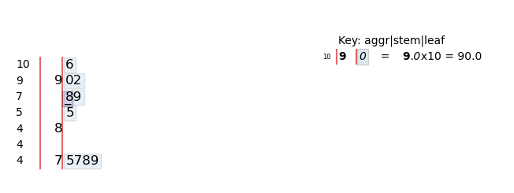

```python
import stemgraphic
import matplotlib.pyplot as plt

# Sample data: test scores
scores = [78, 92, 85, 96, 88, 79, 75, 89, 77, 90]

# Create a stem-and-leaf plot
fig, ax = stemgraphic.stem_graphic(scores)

# Show the plot
plt.show()
```

In the plot, the stem represents the tens place of the scores, and the leaves represent the units place. The distribution of scores can be easily visualized, helping to understand the spread and central tendency of the scores in the class.

### Frequency plot

A frequency plot is a graph that shows the pattern in a set of data by plotting how often particular values of a measure occur.

#### Exercise 30 Histogram

A Histogram is a graphical representation of the distribution of a dataset. It groups numbers into ranges and the height of the bar shows the number of data points that fall into the range, known as the frequency.

#### Components of a Histogram:

1. **Bins**: The intervals into which the data is grouped.
2. **Frequency**: The number of data points in each bin.
3. **Axis**: The x-axis represents the bins and the y-axis represents the frequency.

#### Uses of Histogram:

1. **Visualizing Distribution**: Provides a visual representation of the data distribution.
2. **Identifying Skewness**: Helps in identifying the skewness in the dataset.
3. **Observing Data Concentration**: Shows where the majority of the values are concentrated.

#### Example:

Consider a scenario where a researcher wants to analyze the distribution of ages in a certain population. A histogram can be used to visually represent the distribution of ages, making it easier to analyze the spread and central tendency in the ages.

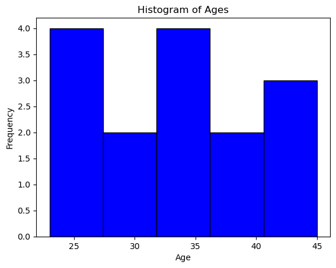

```python
import matplotlib.pyplot as plt

# Sample data: ages of individuals
ages = [23, 25, 26, 27, 29, 30, 32, 33, 35, 36, 38, 40, 42, 43, 45]

# Create a histogram
plt.hist(ages, bins=5, color='blue', edgecolor='black')

# Set the title and labels
plt.title("Histogram of Ages")
plt.xlabel("Age")
plt.ylabel("Frequency")

# Show the plot
plt.show()
```

In the plot, the x-axis represents the age and the y-axis represents the frequency of each age group. The distribution of ages can be easily visualized, helping to understand the spread and central tendency of the ages in the population.

#### Exercise 31 Dot plot

A Dot Plot, also known as a dot chart, is a statistical chart consisting of data points plotted on a fairly simple scale. Dot plots are used for continuous, quantitative, univariate data. They are suitable for smaller datasets and can be used to present data that are organized in categories.

#### Components of a Dot Plot:

1. **Dots**: Each dot represents one observation in the dataset.
2. **Axis**: The axis shows the scale of the variable being plotted.

#### Uses of Dot Plot:

1. **Visualizing Distribution**: Provides a visual representation of the data distribution.
2. **Comparing Groups**: Useful for comparing the distribution of data across different groups or categories.
3. **Identifying Patterns**: Helps in identifying patterns and trends in the dataset.

#### Example:

Consider a scenario where a researcher wants to analyze the distribution of exam scores of students in a class. A dot plot can be used to visually represent the distribution of scores, making it easier to analyze the spread and central tendency in the scores.

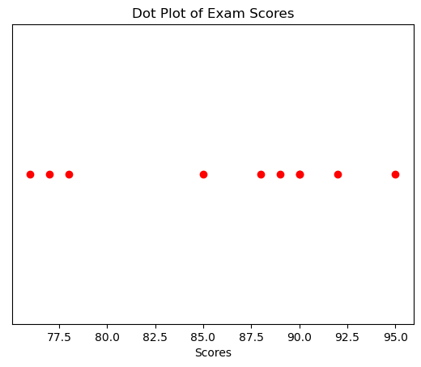

```python
import matplotlib.pyplot as plt

# Sample data: scores of students in a class
scores = [85, 90, 78, 92, 88, 76, 95, 89, 77, 90]

# Create a dot plot
plt.plot(scores, [1] * len(scores), 'ro')

# Set the title and labels
plt.title("Dot Plot of Exam Scores")
plt.yticks([])
plt.xlabel("Scores")

# Show the plot
plt.show()
```

In the plot, each dot represents the score of a student in the class. The distribution of scores can be easily visualized, helping to understand the spread and central tendency of the scores in the class.

#### Exercise 32 Box Plot

A Box Plot, also known as a Whisker Plot, is a graphical representation of the distribution of a dataset. It displays the five-number summary of a dataset: the minimum, first quartile (Q1), median, third quartile (Q3), and maximum.

#### Components of a Box Plot:

1. **Box**: Represents the interquartile range (IQR) where most of the data points lie. It contains the middle 50% of the data.
2. **Median Line**: A line inside the box that indicates the median (middle value) of the dataset.
3. **Whiskers**: Lines extending from the box that indicate the range of the data.
4. **Outliers**: Data points that fall far from the other data points, represented as dots outside the whiskers.

#### Uses of Box Plot:

1. **Visualizing Distribution**: Provides a visual representation of the data distribution.
2. **Identifying Outliers**: Helps in identifying outliers in the dataset.
3. **Comparing Groups**: Useful for comparing the distribution of data across different groups or categories.

#### Example:

Consider a scenario where a researcher wants to analyze the distribution of exam scores of students in a class. A box plot can be used to visually represent the distribution of scores, making it easier to analyze the spread, central tendency, and outliers in the scores.

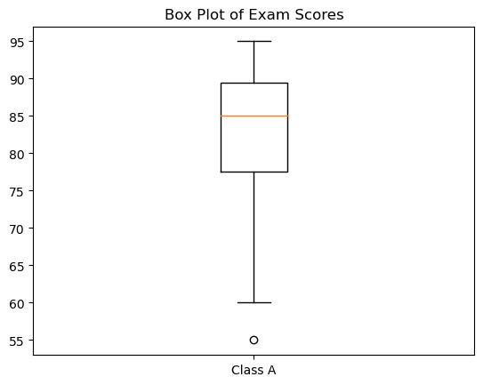

```python
import matplotlib.pyplot as plt

# Sample data: scores of students in a class
scores = [85, 90, 78, 92, 88, 76, 95, 89, 77, 90, 60, 55, 80, 85, 88]

# Create a box plot
plt.boxplot(scores)

# Set the title and labels
plt.title("Box Plot of Exam Scores")
plt.xticks([1], ['Class A'])

# Show the plot
plt.show()
```

In the plot, the box represents the Interquartile Range (IQR) containing the middle 50% of the scores, the median line indicates the median score, the whiskers represent the range of scores, and any dot outside the whiskers is an outlier.

#### Exercise 33 Parallel Box Plot

A Parallel Box Plot, also known as a side-by-side box plot, is a graphical representation that allows the comparison of multiple datasets or groups. It displays the distribution and summary statistics of different datasets side by side along the same axis, making it easier to compare them. Each box plot in a parallel box plot represents one dataset.

#### Components of a Parallel Box Plot:

1. **Box**: The main part of the plot, representing the interquartile range (IQR), which contains the middle 50% of the data.
2. **Median Line**: A line inside the box that indicates the median of the dataset.
3. **Whiskers**: Lines extending from the box that indicate the variability of the data outside the upper and lower quartiles.
4. **Outliers**: Points outside the whiskers that represent individual data points that fall far from the other data points.

#### Uses of Parallel Box Plot:

1. **Comparing Distributions**: Parallel box plots are used to visually compare the distributions of multiple groups or datasets.
2. **Identifying Variability**: They help in identifying the spread and skewness in different datasets.
3. **Detecting Outliers**: Parallel box plots can be used to easily detect outliers in multiple datasets.
4. **Analyzing Central Tendency**: They allow the analysis of the central tendency of different groups by displaying their medians.

#### Example:

Consider a scenario where a researcher wants to compare the exam scores of students from different classes. A parallel box plot can be used to visually compare the distribution of scores in each class, identify any significant differences in performance, and detect any outliers.

```python
import seaborn as sns
import matplotlib.pyplot as plt
import pandas as pd

# Sample data: scores of students in three different classes
data = {
    "Class A": [85, 90, 78, 92, 88, 76, 95, 89, 77, 90],
    "Class B": [80, 85, 88, 84, 82, 75, 89, 86, 80, 87],
    "Class C": [78, 79, 80, 74, 76, 77, 85, 80, 79, 78]
}

print(data)
```

```
{'Class A': [85, 90, 78, 92, 88, 76, 95, 89, 77, 90], 'Class B': [80, 85, 88, 84, 82, 75, 89, 86, 80, 87], 'Class C': [78, 79, 80, 74, 76, 77, 85, 80, 79, 78]}
```

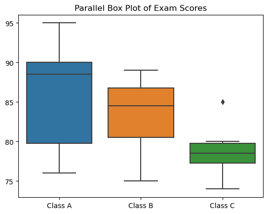

```python
# Create a parallel box plot
sns.boxplot(data=pd.DataFrame(data))
plt.title("Parallel Box Plot of Exam Scores")
plt.show()
```

#### Exercise 34 Customized Box Plot

In this exercise, you will learn to create a customized box plot using Python's Matplotlib library. The objective is to understand how to modify various components of a box plot, such as the box, whiskers, caps, medians, and fliers, to enhance the visual representation of data.

#### Details:

You will work with a sample dataset and create a box plot with the following customizations:

1. Different colors for each box in the plot.
2. Customized whiskers with a specific color, linewidth, and linestyle.
3. Customized caps with a specific color and linewidth.
4. Customized medians with a specific color and linewidth.
5. Customized fliers with a specific marker, color, and alpha value.

#### Code Explanation:

- The `create_customized_boxplot` function is used to create the box plot. It takes a dataset as input and applies various customizations to the box plot components.
- The `customize_component` helper function is used to apply custom properties to the whiskers, caps, and medians. It takes a list of components and additional keyword arguments for the properties to be set.
- The `for` loop for fliers is kept separate as it has different properties to be set.

#### Expected Results:

After executing the code, you will obtain a box plot with the following customizations:

- Boxes with colors: `['#0000FF', '#00FF00', '#FFFF00', '#FF00FF']`.
- Whiskers with color `'#8B008B'`, linewidth `1.5`, and linestyle `":"`.
- Caps with color `'#8B008B'` and linewidth `2`.
- Medians with color `'red'` and linewidth `3`.
- Fliers with marker `'D'`, color `'#e7298a'`, and alpha `0.5`.

#### Steps to Execute:

1. Define the sample data for the box plot.
2. Call the `create_customized_boxplot` function with the sample data as an argument.
3. Observe the customized box plot displayed as output.

By completing this exercise, you will gain hands-on experience in creating and customizing box plots using Matplotlib, enhancing your data visualization skills.

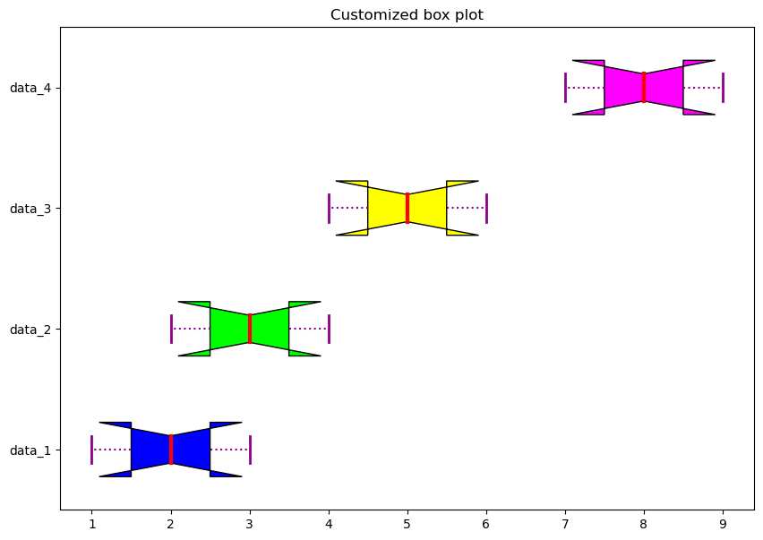

```python
import matplotlib.pyplot as plt

def create_customized_boxplot(data):
    # Create a figure and axis with specific size
    fig, ax = plt.subplots(figsize=(10, 7))

    # Create a box plot
    bp = ax.boxplot(data, patch_artist=True, notch=True, vert=0)

    # Set colors for each box
    colors = ['#0000FF', '#00FF00', '#FFFF00', '#FF00FF']
    for patch, color in zip(bp['boxes'], colors):
        patch.set_facecolor(color)

    # Customize whiskers, caps, medians, and fliers
    customize_component(bp['whiskers'], color='#8B008B', linewidth=1.5, linestyle=":")
    customize_component(bp['caps'], color='#8B008B', linewidth=2)
    customize_component(bp['medians'], color='red', linewidth=3)
    for flier in bp['fliers']:
        flier.set(marker='D', color='#e7298a', alpha=0.5)

    # Set y-axis labels and title
    ax.set_yticklabels(['data_1', 'data_2', 'data_3', 'data_4'])
    plt.title("Customized box plot")

    # Remove top and right axes ticks
    ax.get_xaxis().tick_bottom()
    ax.get_yaxis().tick_left()

    # Display the plot
    plt.show()

def customize_component(components, **kwargs):
    for component in components:
        component.set(**kwargs)

# Sample data for the box plot
data = [[1, 2, 3], [2, 3, 4], [4, 5, 6], [7, 8, 9]]

# Call the function to create the customized box plot
create_customized_boxplot(data)
```

Revised Date: October 9, 2023